# Forecasting and forecast evaluation in mvgam

Nicholas J Clark

2026-01-19

The purpose of this vignette is to show how the `mvgam` package can be used to produce probabilistic forecasts and to evaluate those forecasts using a variety of proper scoring rules.

## Simulating discrete time series

We begin by simulating some data to show how forecasts are computed and evaluated in `mvgam`. The `sim_mvgam()` function can be used to simulate series that come from a variety of response distributions as well as seasonal patterns and/or dynamic temporal patterns. Here we simulate a collection of three time count-valued series. These series all share the same seasonal pattern but have different temporal dynamics. By setting `trend_model = GP()` and `prop_trend = 0.75`, we are generating time series that have smooth underlying temporal trends (evolving as Gaussian Processes with squared exponential kernel) and moderate seasonal patterns. The observations are Poisson-distributed and we allow 10% of observations to be missing.

```r
set.seed(1)
simdat <- sim_mvgam(
  T = 100,
  n_series = 3,
  mu = 2,
  trend_model = GP(),
  prop_trend = 0.75,
  family = poisson(),
  prop_missing = 0.10
)
```

The returned object is a `list` containing training and testing data (`sim_mvgam()` automatically splits the data into these folds for us) together with some other information about the data generating process that was used to simulate the data

```r
str(simdat)
```

```
#> List of 6
#>  $ data_train        :'data.frame':  225 obs. of  5 variables:
#>   ..$ y     : int [1:225] 6 NA 11 2 5 20 7 8 NA 11 ...
#>   ..$ season: int [1:225] 1 1 1 2 2 2 3 3 3 4 ...
#>   ..$ year  : int [1:225] 1 1 1 1 1 1 1 1 1 1 ...
#>   ..$ series: Factor w/ 3 levels "series_1","series_2",..: 1 2 3 1 2 3 1 2 3 1 ...
#>   ..$ time  : int [1:225] 1 1 1 2 2 2 3 3 3 4 ...
#>  $ data_test         :'data.frame':  75 obs. of  5 variables:
#>   ..$ y     : int [1:75] 4 23 8 3 NA 3 1 20 8 3 ...
#>   ..$ season: int [1:75] 4 4 4 5 5 5 6 6 6 7 ...
#>   ..$ year  : int [1:75] 7 7 7 7 7 7 7 7 7 7 ...
#>   ..$ series: Factor w/ 3 levels "series_1","series_2",..: 1 2 3 1 2 3 1 2 3 1 ...
#>   ..$ time  : int [1:75] 76 76 76 77 77 77 78 78 78 79 ...
#>  $ true_corrs        : num [1:3, 1:3] 1 0.0861 0.1161 0.0861 1 ...
#>  $ true_trends       : num [1:100, 1:3] -0.851 -0.758 -0.664 -0.571 -0.48 ...
#>  $ global_seasonality: num [1:100] -0.966 -0.197 0.771 1.083 0.37 ...
#>  $ trend_params      :List of 2
#>   ..$ alpha: num [1:3] 0.883 0.936 1.036
#>   ..$ rho  : num [1:3] 7.54 4.01 7.49
```

Each series in this case has a shared seasonal pattern. The resulting time series are similar to what we might encounter when dealing with count-valued data that can take small counts:

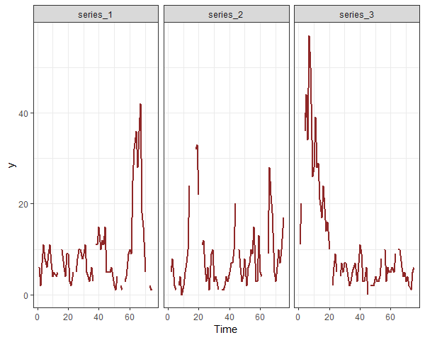

```r
plot_mvgam_series(
  data = simdat$data_train,
  series = "all"
)
```

For individual series, we can plot the training and testing data, as well as some more specific features of the observed data:

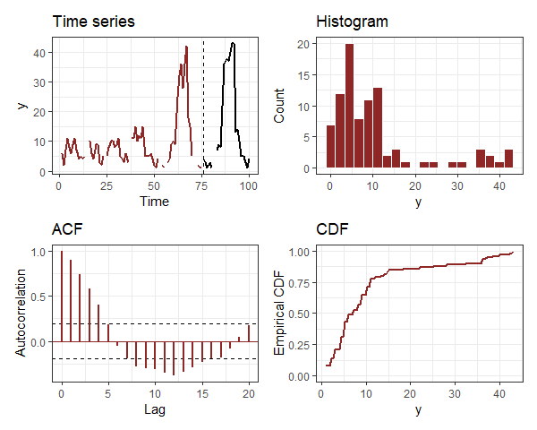

```r
plot_mvgam_series(
  data = simdat$data_train,
  newdata = simdat$data_test,
  series = 1
)
```

### Modelling dynamics with splines

The first model we will fit uses a shared cyclic spline to capture the repeated seasonality, as well as series-specific splines of time to capture the long-term dynamics. We allow the temporal splines to be fairly complex so they can capture as much of the temporal variation as possible:

```r
mod1 <- mvgam(
  y ~ s(season, bs = "cc", k = 8) +
    s(time, by = series, bs = "cr", k = 20),
  knots = list(season = c(0.5, 12.5)),
  trend_model = "None",
  data = simdat$data_train,
  silent = 2
)
```

```r
summary(mod1, include_betas = FALSE)
```

[output not shown]

And we can plot the conditional effects of the splines (on the link scale) to see that they are estimated to be highly nonlinear

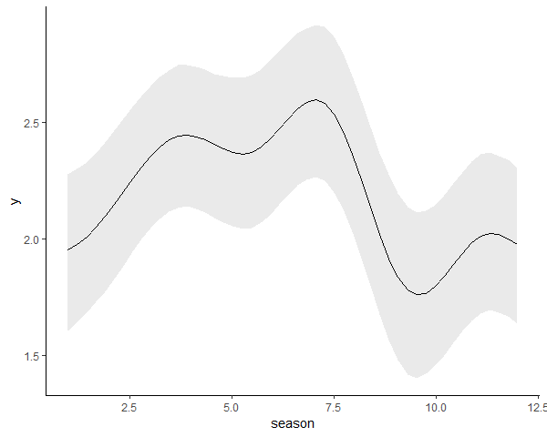

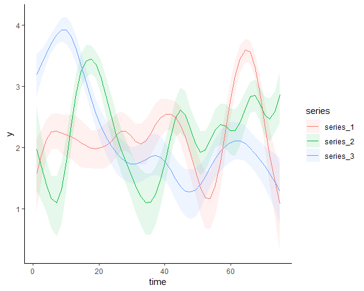

```r
conditional_effects(mod1, type = "link")
```

### Modelling dynamics with a correlated AR1

Before showing how to produce and evaluate forecasts, we will fit a second model to these data so the two models can be compared. This model is equivalent to the above, except we now use a correlated AR(1) process to model series-specific dynamics. See `?AR` for more details.

```r
mod2 <- mvgam(y ~ 1,
  trend_formula = ~ s(season, bs = "cc", k = 8) - 1,
  trend_knots = list(season = c(0.5, 12.5)),
  trend_model = AR(cor = TRUE),
  noncentred = TRUE,
  data = simdat$data_train,
  silent = 1
)
```

The summary for this model now contains information on the autoregressive and process error parameters for each time series:

```r
summary(mod2, include_betas = FALSE)
```

```
#> GAM observation formula:
#> y ~ 1
#> <environment: 0x0000022e41d5a728>
#>
#> GAM process formula:
#> ~s(season, bs = "cc", k = 8) - 1
#> <environment: 0x0000022e41d5a728>
#>
#> Family:
#> poisson
#>
#> Link function:
#> log
#>
#> Trend model:
#> AR(cor = TRUE)
#>
#> N process models:
#> 3
#>
#> N series:
#> 3
#>
#> N timepoints:
#> 75
#>
#> Status:
#> Fitted using Stan
#> 4 chains, each with iter = 1000; warmup = 500; thin = 1
#> Total post-warmup draws = 2000
#>
#> GAM observation model coefficient (beta) estimates:
#>             2.5% 50% 97.5% Rhat n_eff
#> (Intercept)  1.8   2   2.4 1.01   512
#>
#> standard deviation:
#>          2.5%  50% 97.5% Rhat n_eff
#> sigma[1] 0.23 0.32  0.44 1.01   318
#> sigma[2] 0.30 0.43  0.58 1.01   498
#> sigma[3] 0.18 0.25  0.36 1.01   329
```

[output cut: 9 more lines]

```
#> s(season) 1.737      6  23.81 1.22e-05 ***
#> ---
#> Signif. codes:  0 '***' 0.001 '**' 0.01 '*' 0.05 '.' 0.1 ' ' 1
#>
#> Stan MCMC diagnostics:
#> ✔ No issues with effective samples per iteration
#> ✔ Rhat looks good for all parameters
#> ✔ No issues with divergences
#> ✔ No issues with maximum tree depth
#>
#> Samples were drawn using sampling(hmc). For each parameter, n_eff is a
#>   crude measure of effective sample size, and Rhat is the potential scale
#>   reduction factor on split MCMC chains (at convergence, Rhat = 1)
#>
#> Use how_to_cite() to get started describing this model
```

We can plot the posteriors for these parameters, and for any other parameter for that matter, using `bayesplot` routines. First the autoregressive parameters:

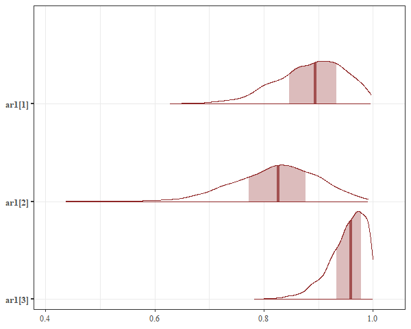

```r
mcmc_plot(mod2, variable = "ar", regex = TRUE, type = "areas")
```

And now the variance ($\sigma$) parameters:

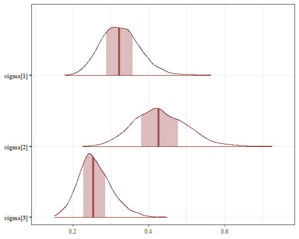

```r
mcmc_plot(mod2, variable = "sigma", regex = TRUE, type = "areas")
```

We can again plot the conditional seasonal effect:

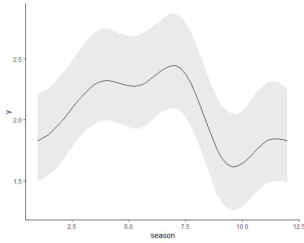

```r
conditional_effects(mod2, type = "link")
```

The estimates for the seasonal component are fairly similar for the two models, but below we will see if they produce similar forecasts

## Forecasting with the `forecast()` function

Probabilistic forecasts can be computed in two main ways in `mvgam`. The first is to take a model that was fit only to training data (as we did above in the two example models) and produce temporal predictions from the posterior predictive distribution by feeding `newdata` to the `forecast()` function. It is crucial that any `newdata` fed to the `forecast()` function follows on sequentially from the data that was used to fit the model (this is not internally checked by the package because it might be a headache to do so when data are not supplied in a specific time-order). When calling the `forecast()` function, you have the option to generate different kinds of predictions (i.e. predicting on the link scale, response scale or to produce expectations; see `?forecast.mvgam` for details). We will use the default and produce forecasts on the response scale, which is the most common way to evaluate forecast distributions

```r
fc_mod1 <- forecast(mod1, newdata = simdat$data_test)
fc_mod2 <- forecast(mod2, newdata = simdat$data_test)
```

The objects we have created are of class `mvgam_forecast`, which contain information on hindcast distributions, forecast distributions and true observations for each series in the data:

```r
str(fc_mod1)
```

[output not shown]

We can plot the forecasts for some series from each model using the `S3 plot` method for objects of this class:

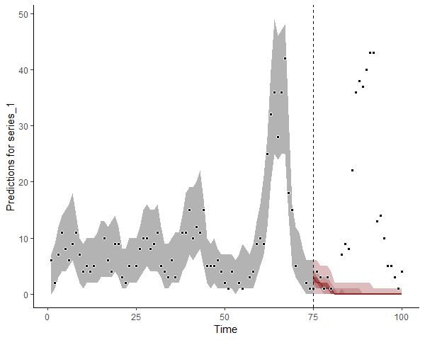

```r
plot(fc_mod1, series = 1)
```

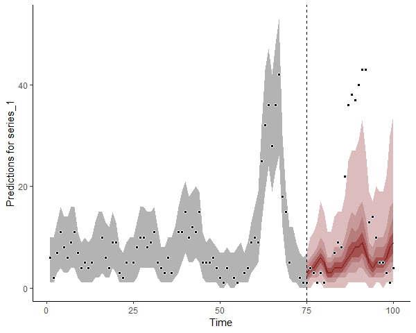

```r
plot(fc_mod2, series = 1)
```

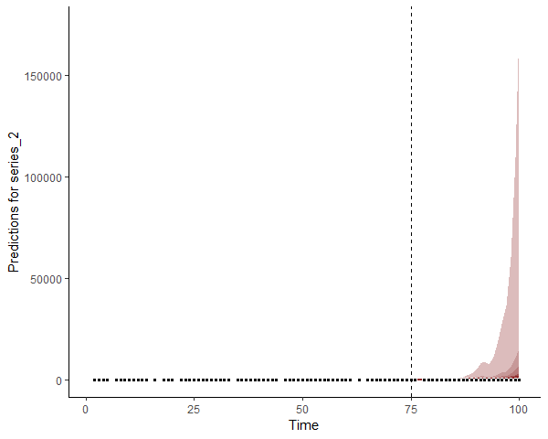

```r
plot(fc_mod1, series = 2)
```

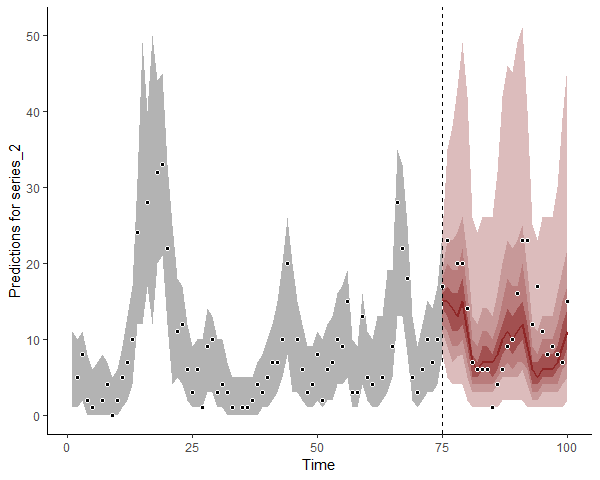

```r
plot(fc_mod2, series = 2)
```

Clearly the two models do not produce equivalent forecasts. We will come back to scoring these forecasts in a moment.

## Forecasting with `newdata` in `mvgam()`

The second way we can produce forecasts in `mvgam` is to feed the testing data directly to the `mvgam()` function as `newdata`. This will include the testing data as missing observations so that they are automatically predicted from the posterior predictive distribution using the `generated quantities` block in `Stan`. As an example, we can refit `mod2` but include the testing data for automatic forecasts:

```r
mod2 <- mvgam(y ~ 1,
  trend_formula = ~ s(season, bs = "cc", k = 8) - 1,
  trend_knots = list(season = c(0.5, 12.5)),
  trend_model = AR(cor = TRUE),
  noncentred = TRUE,
  data = simdat$data_train,
  newdata = simdat$data_test,
  silent = 2
)
```

Because the model already contains a forecast distribution, we do not need to feed `newdata` to the `forecast()` function:

```r
fc_mod2 <- forecast(mod2)
```

The forecasts will be nearly identical to those calculated previously:

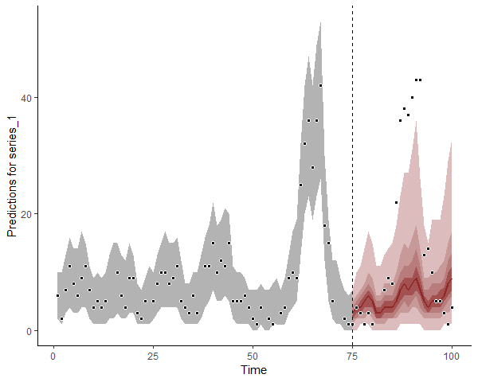

```r
plot(fc_mod2, series = 1)
```

## Scoring forecast distributions

A primary purpose of the `mvgam_forecast` class is to readily allow forecast evaluations for each series in the data, using a variety of possible scoring functions. See `?mvgam::score.mvgam_forecast` to view the types of scores that are available. A useful scoring metric is the Continuous Rank Probability Score (CRPS). A CRPS value is similar to what we might get if we calculated a weighted absolute error using the full forecast distribution.

```r
crps_mod1 <- score(fc_mod1, score = "crps")
str(crps_mod1)
```

```
#> List of 4
#>  $ series_1  :'data.frame':  25 obs. of  5 variables:
#>   ..$ score         : num [1:25] 0.993 0.817 0.334 0.998 0.277 ...
#>   ..$ in_interval   : num [1:25] 1 1 1 1 1 NA NA 0 0 0 ...
#>   ..$ interval_width: num [1:25] 0.9 0.9 0.9 0.9 0.9 0.9 0.9 0.9 0.9 0.9 ...
#>   ..$ eval_horizon  : int [1:25] 1 2 3 4 5 6 7 8 9 10 ...
#>   ..$ score_type    : chr [1:25] "crps" "crps" "crps" "crps" ...
#>  $ series_2  :'data.frame':  25 obs. of  5 variables:
#>   ..$ score         : num [1:25] 2.01 NA 6.55 14.69 17.43 ...
#>   ..$ in_interval   : num [1:25] 1 NA 1 1 1 0 0 0 0 0 ...
#>   ..$ interval_width: num [1:25] 0.9 0.9 0.9 0.9 0.9 0.9 0.9 0.9 0.9 0.9 ...
#>   ..$ eval_horizon  : int [1:25] 1 2 3 4 5 6 7 8 9 10 ...
#>   ..$ score_type    : chr [1:25] "crps" "crps" "crps" "crps" ...
#>  $ series_3  :'data.frame':  25 obs. of  5 variables:
#>   ..$ score         : num [1:25] 3.487 0.463 4.064 0.5 NA ...
#>   ..$ in_interval   : num [1:25] 0 1 0 1 NA 1 1 0 0 NA ...
#>   ..$ interval_width: num [1:25] 0.9 0.9 0.9 0.9 0.9 0.9 0.9 0.9 0.9 0.9 ...
#>   ..$ eval_horizon  : int [1:25] 1 2 3 4 5 6 7 8 9 10 ...
#>   ..$ score_type    : chr [1:25] "crps" "crps" "crps" "crps" ...
#>  $ all_series:'data.frame':  25 obs. of  3 variables:
#>   ..$ score       : num [1:25] 6.49 NA 10.95 16.18 NA ...
#>   ..$ eval_horizon: int [1:25] 1 2 3 4 5 6 7 8 9 10 ...
#>   ..$ score_type  : chr [1:25] "sum_crps" "sum_crps" "sum_crps" "sum_crps" ...
```

```r
crps_mod1$series_1
```

```
#>         score in_interval interval_width eval_horizon score_type
#> 1   0.9932195           1            0.9            1       crps
#> 2   0.8173380           1            0.9            2       crps
#> 3   0.3338443           1            0.9            3       crps
#> 4   0.9980710           1            0.9            4       crps
#> 5   0.2773030           1            0.9            5       crps
#> 6          NA          NA            0.9            6       crps
#> 7          NA          NA            0.9            7       crps
#> 8   6.1295615           0            0.9            8       crps
#> 9   8.2855480           0            0.9            9       crps
#> 10  7.4110365           0            0.9           10       crps
#> 11 21.3898007           0            0.9           11       crps
#> 12 35.2857677           0            0.9           12       crps
#> 13 37.2882082           0            0.9           13       crps
#> 14 36.4251945           0            0.9           14       crps
#> 15 39.3858395           0            0.9           15       crps
#> 16 42.3677532           0            0.9           16       crps
#> 17 42.5461592           0            0.9           17       crps
#> 18 12.7316780           0            0.9           18       crps
#> 19 13.7700235           0            0.9           19       crps
#> 20  9.7282697           0            0.9           20       crps
#> 21  4.7711443           0            0.9           21       crps
#> 22  4.8054445           0            0.9           22       crps
#> 23  2.7825032           0            0.9           23       crps
#> 24  0.8591737           1            0.9           24       crps
#> 25  3.7808390           0            0.9           25       crps
```

The returned list contains a `data.frame` for each series in the data that shows the CRPS score for each evaluation in the testing data, along with some other useful information about the fit of the forecast distribution. In particular, we are given a logical value (1s and 0s) telling us whether the true value was within a pre-specified credible interval (i.e. the coverage of the forecast distribution). The default interval width is 0.9, so we would hope that the values in the `in_interval` column take a 1 approximately 90% of the time. This value can be changed if you wish to compute different coverages, say using a 60% interval:

```r
crps_mod1 <- score(fc_mod1, score = "crps", interval_width = 0.6)
crps_mod1$series_1
```

```
#>         score in_interval interval_width eval_horizon score_type
#> 1   0.9932195           1            0.6            1       crps
#> 2   0.8173380           1            0.6            2       crps
#> 3   0.3338443           1            0.6            3       crps
#> 4   0.9980710           1            0.6            4       crps
#> 5   0.2773030           1            0.6            5       crps
#> 6          NA          NA            0.6            6       crps
#> 7          NA          NA            0.6            7       crps
#> 8   6.1295615           0            0.6            8       crps
#> 9   8.2855480           0            0.6            9       crps
#> 10  7.4110365           0            0.6           10       crps
#> 11 21.3898007           0            0.6           11       crps
#> 12 35.2857677           0            0.6           12       crps
#> 13 37.2882082           0            0.6           13       crps
#> 14 36.4251945           0            0.6           14       crps
#> 15 39.3858395           0            0.6           15       crps
#> 16 42.3677532           0            0.6           16       crps
#> 17 42.5461592           0            0.6           17       crps
#> 18 12.7316780           0            0.6           18       crps
#> 19 13.7700235           0            0.6           19       crps
#> 20  9.7282697           0            0.6           20       crps
#> 21  4.7711443           0            0.6           21       crps
#> 22  4.8054445           0            0.6           22       crps
#> 23  2.7825032           0            0.6           23       crps
#> 24  0.8591737           0            0.6           24       crps
#> 25  3.7808390           0            0.6           25       crps
```

We can also compare forecasts against out of sample observations using the [Expected Log Predictive Density (ELPD; also known as the log score)](https://link.springer.com/article/10.1007/s11222-016-9696-4). The ELPD is a strictly proper scoring rule that can be applied to any distributional forecast, but to compute it we need predictions on the link scale rather than on the outcome scale. This is where it is advantageous to change the type of prediction we can get using the `forecast()` function:

```r
link_mod1 <- forecast(mod1, newdata = simdat$data_test, type = "link")
score(link_mod1, score = "elpd")$series_1
```

```
#>         score eval_horizon score_type
#> 1   -2.155156            1       elpd
#> 2   -1.956860            2       elpd
#> 3   -1.242909            3       elpd
#> 4   -2.208022            4       elpd
#> 5   -1.218081            5       elpd
#> 6          NA            6       elpd
#> 7          NA            7       elpd
#> 8   -7.113590            8       elpd
#> 9   -8.499192            9       elpd
#> 10  -7.975085           10       elpd
#> 11 -18.627673           11       elpd
#> 12 -30.187736           12       elpd
#> 13 -28.528770           13       elpd
#> 14 -27.474431           14       elpd
#> 15 -27.138400           15       elpd
#> 16 -24.018949           16       elpd
#> 17 -28.766709           17       elpd
#> 18  -9.455606           18       elpd
#> 19 -10.169118           19       elpd
#> 20  -7.741233           20       elpd
#> 21  -6.998068           21       elpd
#> 22  -7.030657           22       elpd
#> 23  -5.715523           23       elpd
#> 24  -3.015423           24       elpd
#> 25  -6.271717           25       elpd
```

Finally, when we have multiple time series it may also make sense to use a multivariate proper scoring rule. `mvgam` offers two such options: the Energy score and the Variogram score. The first penalizes forecast distributions that are less well calibrated against the truth, while the second penalizes forecasts that do not capture the observed true correlation structure. Which score to use depends on your goals, but both are very easy to compute:

```r
energy_mod2 <- score(fc_mod2, score = "energy")
str(energy_mod2)
```

```
#> List of 4
#>  $ series_1  :'data.frame':  25 obs. of  3 variables:
#>   ..$ in_interval   : num [1:25] 1 1 1 1 1 NA NA 1 1 1 ...
#>   ..$ interval_width: num [1:25] 0.9 0.9 0.9 0.9 0.9 0.9 0.9 0.9 0.9 0.9 ...
#>   ..$ eval_horizon  : int [1:25] 1 2 3 4 5 6 7 8 9 10 ...
#>  $ series_2  :'data.frame':  25 obs. of  3 variables:
#>   ..$ in_interval   : num [1:25] 1 NA 1 1 1 1 1 1 1 1 ...
#>   ..$ interval_width: num [1:25] 0.9 0.9 0.9 0.9 0.9 0.9 0.9 0.9 0.9 0.9 ...
#>   ..$ eval_horizon  : int [1:25] 1 2 3 4 5 6 7 8 9 10 ...
#>  $ series_3  :'data.frame':  25 obs. of  3 variables:
#>   ..$ in_interval   : num [1:25] 1 1 1 1 NA 1 1 1 1 NA ...
#>   ..$ interval_width: num [1:25] 0.9 0.9 0.9 0.9 0.9 0.9 0.9 0.9 0.9 0.9 ...
#>   ..$ eval_horizon  : int [1:25] 1 2 3 4 5 6 7 8 9 10 ...
#>  $ all_series:'data.frame':  25 obs. of  3 variables:
#>   ..$ score       : num [1:25] 4.74 NA 5.03 5.36 NA ...
#>   ..$ eval_horizon: int [1:25] 1 2 3 4 5 6 7 8 9 10 ...
#>   ..$ score_type  : chr [1:25] "energy" "energy" "energy" "energy" ...
```

The returned object still provides information on interval coverage for each individual series, but there is only a single score per horizon now (which is provided in the `all_series` slot):

```r
energy_mod2$all_series
```

```
#>        score eval_horizon score_type
#> 1   4.736450            1     energy
#> 2         NA            2     energy
#> 3   5.025547            3     energy
#> 4   5.363993            4     energy
#> 5         NA            5     energy
#> 6         NA            6     energy
#> 7         NA            7     energy
#> 8   3.918395            8     energy
#> 9   4.113319            9     energy
#> 10        NA           10     energy
#> 11 13.149358           11     energy
#> 12 22.547040           12     energy
#> 13        NA           13     energy
#> 14 21.170257           14     energy
#> 15 24.184433           15     energy
#> 16 25.110374           16     energy
#> 17 27.945911           17     energy
#> 18  6.180386           18     energy
#> 19 10.674543           19     energy
#> 20  4.093666           20     energy
#> 21  2.870332           21     energy
#> 22  3.443291           22     energy
#> 23        NA           23     energy
#> 24  8.866093           24     energy
#> 25  7.883124           25     energy
```

You can use your score(s) of choice to compare different models. For example, we can compute and plot the difference in CRPS scores for each series in data. Here, a negative value means the AR(1) model (`mod2`) is better, while a positive value means the spline model (`mod1`) is better.

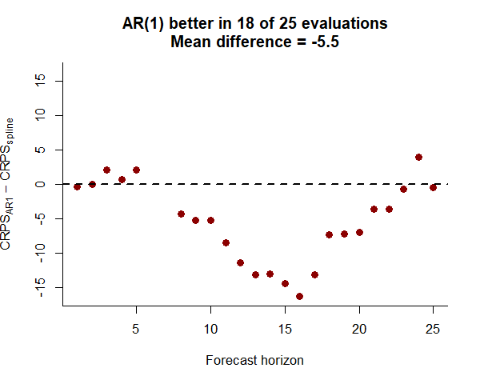

```r
crps_mod1 <- score(fc_mod1, score = "crps")
crps_mod2 <- score(fc_mod2, score = "crps")

diff_scores <- crps_mod2$series_1$score -
  crps_mod1$series_1$score
plot(diff_scores,
  pch = 16, cex = 1.25, col = "darkred",
  ylim = c(
    -1 * max(abs(diff_scores), na.rm = TRUE),
    max(abs(diff_scores), na.rm = TRUE)
  ),
  bty = "l",
  xlab = "Forecast horizon",
  ylab = expression(CRPS[AR1] ~ -~ CRPS[spline])
)
abline(h = 0, lty = "dashed", lwd = 2)
ar1_better <- length(which(diff_scores < 0))
title(main = paste0(
  "AR(1) better in ",
  ar1_better,
  " of ",
  length(diff_scores),
  " evaluations",
  "\nMean difference = ",
  round(mean(diff_scores, na.rm = TRUE), 2)
))
```

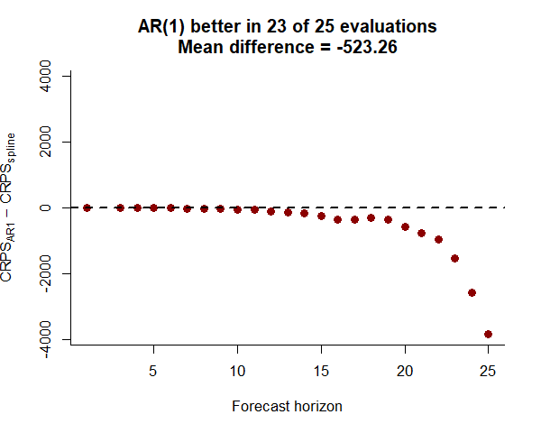

```r
diff_scores <- crps_mod2$series_2$score -
  crps_mod1$series_2$score
plot(diff_scores,
  pch = 16, cex = 1.25, col = "darkred",
  ylim = c(
    -1 * max(abs(diff_scores), na.rm = TRUE),
    max(abs(diff_scores), na.rm = TRUE)
  ),
  bty = "l",
  xlab = "Forecast horizon",
  ylab = expression(CRPS[AR1] ~ -~ CRPS[spline])
)
abline(h = 0, lty = "dashed", lwd = 2)
ar1_better <- length(which(diff_scores < 0))
title(main = paste0(
  "AR(1) better in ",
  ar1_better,
  " of ",
  length(diff_scores),
  " evaluations",
  "\nMean difference = ",
  round(mean(diff_scores, na.rm = TRUE), 2)
))
```

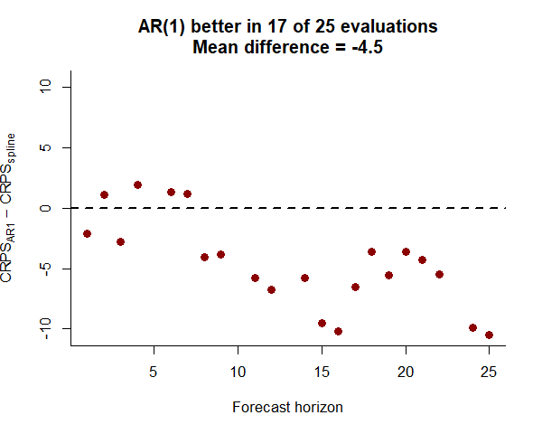

```r
diff_scores <- crps_mod2$series_3$score -
  crps_mod1$series_3$score
plot(diff_scores,
  pch = 16, cex = 1.25, col = "darkred",
  ylim = c(
    -1 * max(abs(diff_scores), na.rm = TRUE),
    max(abs(diff_scores), na.rm = TRUE)
  ),
  bty = "l",
  xlab = "Forecast horizon",
  ylab = expression(CRPS[AR1] ~ -~ CRPS[spline])
)
abline(h = 0, lty = "dashed", lwd = 2)
ar1_better <- length(which(diff_scores < 0))
title(main = paste0(
  "AR(1) better in ",
  ar1_better,
  " of ",
  length(diff_scores),
  " evaluations",
  "\nMean difference = ",
  round(mean(diff_scores, na.rm = TRUE), 2)
))
```

The correlated AR(1) model consistently gives better forecasts, and the difference between scores tends to grow as the forecast horizon increases. This is not unexpected given the way that splines linearly extrapolate outside the range of training data

## Further reading

The following papers and resources offer useful material about Bayesian forecasting and proper scoring rules:

Clark N.J., et al. [Beyond single-species models: leveraging multispecies forecasts to navigate the dynamics of ecological predictability](https://peerj.com/articles/18929/). *PeerJ* 13:e18929 (2025) https://doi.org/10.7717/peerj.18929

Hyndman, Rob J., and George Athanasopoulos. [Forecasting: principles and practice](https://otexts.com/fpp3/distaccuracy.html). *OTexts*, (2018).

Gneiting, Tilmann, and Adrian E. Raftery. [Strictly proper scoring rules, prediction, and estimation](https://www.tandfonline.com/doi/abs/10.1198/016214506000001437) *Journal of the American statistical Association* 102.477 (2007) 359-378.

Simonis, Juniper L., et al. [Evaluating probabilistic ecological forecasts](https://esajournals.onlinelibrary.wiley.com/doi/full/10.1002/ecy.3431) *Ecology* 102.8 (2021) e03431.

## Interested in contributing?

I’m actively seeking PhD students and other researchers to work in the areas of ecological forecasting, multivariate model evaluation and development of `mvgam`. Please see [this small list of opportunities on my website](https://ecogambler.netlify.app/opportunities/) and do reach out if you are interested (n.clark’at’uq.edu.au)